# Data Tidak Stasioner

Dewi Kunthi Siswati Suryo

2023-10-01

```r
library(ggplot2)
library(tsibble)
library(tseries)
library(MASS)
```

```r
library("forecast")
```

```r
library("graphics")
library("TTR")
library("TSA")
```

# Impor Data

```r
library(rio)
data <- import("https://raw.githubusercontent.com/dewidesis/MPDW-Prak/main/Pertemuan%205/Microsoft%20Stock%20Market%20Analysis.csv")
data
```

```
##     Periode   Open
## 1         1 222.53
## 2         2 217.26
## 3         3 212.17
## 4         4 214.04
## 5         5 218.68
## 6         6 218.47
## 7         7 216.50
## 8         8 214.02
## 9         9 215.91
## 10       10 213.52
## 11       11 213.75
## 12       12 217.70
## 13       13 224.70
## 14       14 227.08
```

[output cut: 216 more lines]

```r
str(data)
```

```
## 'data.frame':    230 obs. of  2 variables:
##  $ Periode: int  1 2 3 4 5 6 7 8 9 10 ...
##  $ Open   : num  223 217 212 214 219 ...
```

```r
dim(data)
```

```
## [1] 230   2
```

# Data Penuh

## Time Series

Mengubah data agar terbaca sebagai data deret waktu dengan fungsi `ts()` .

```r
data.ts <- ts(data$Open)
```

Menampilkan ringkasan data

```r
summary(data.ts)
```

```
##    Min. 1st Qu.  Median    Mean 3rd Qu.    Max.
##   212.2   242.3   260.9   270.2   296.2   344.6
```

## Tidak Stasioner dalam Rataan dan Ragam

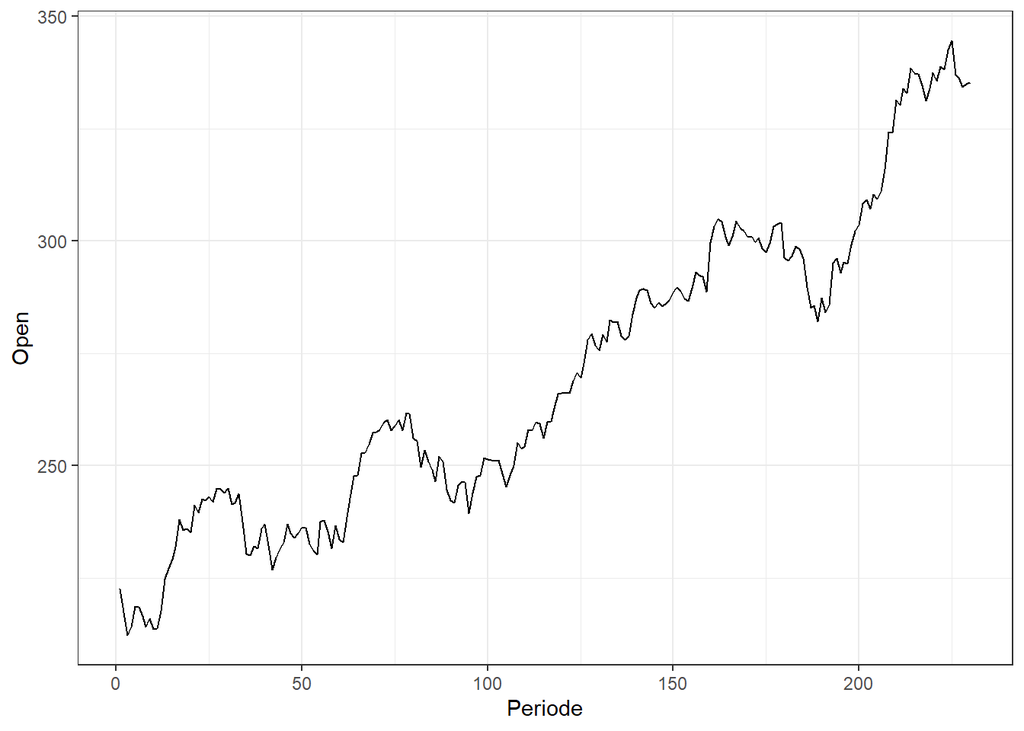

```r
plot_data <- data.ts |> as_tsibble() |>
  ggplot(aes(x = data$Periode, y = data$Open)) + geom_line() + theme_bw() +
  xlab("Periode") + ylab("Open")
plot_data
```

```r
mean(data.ts)
```

```
## [1] 270.2033
```

Berdasarkan plot time series tersebut, terlihat bahwa data tidak stasioner dalam rataan, ditandai dengan adanya trend pada data dan tidak stasioner dalam ragam, ditandai dengan adanya perbedaan lebar pita pada plot

### Plot ACF

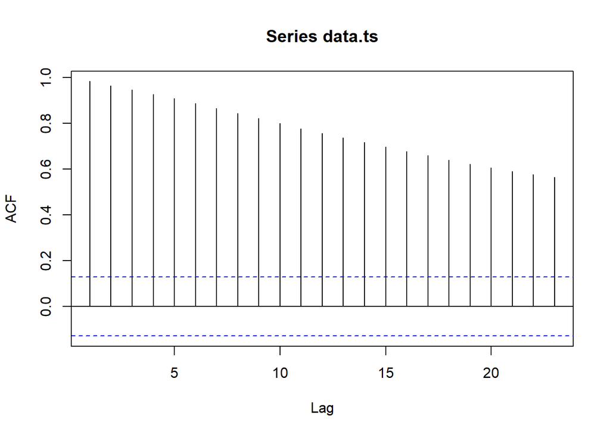

```r
acf(data.ts)
```

Berdasarkan plot ACF, terlihat bahwa plot ACF pada data tersebut menurun secara perlahan (*tails off slowly*) yang menandakan data tidak stasioner dalam rataan.

### Uji ADF

```r
tseries::adf.test(data.ts)
```

```
##
##  Augmented Dickey-Fuller Test
##
## data:  data.ts
## Dickey-Fuller = -2.7797, Lag order = 6, p-value = 0.2484
## alternative hypothesis: stationary
```

$H_0$ : Data tidak stasioner dalam rataan

$H_1$ : Data stasioner dalam rataan

Berdasarkan uji ADF tersebut, didapat *p-value* sebesar 0.2484 yang lebih besar dari taraf nyata 5% sehingga tidak tolak $H_0$ dan menandakan bahwa data tidak stasioner dalam rataan. Hal ini sesuai dengan hasil eksplorasi menggunakan plot time series dan plot ACF.

### Plot Box-Cox

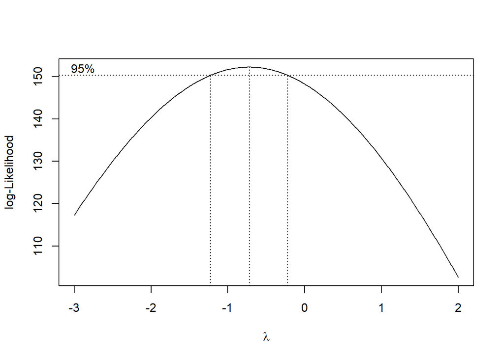

```r
index <- seq(1:230) #sebanyak row data
bc = boxcox(data.ts~index, lambda = seq(-3,2,by=0.01))
```

```r
#Nilai Rounded Lambda
lambda <- bc$x[which.max(bc$y)]
lambda
```

```
## [1] -0.72
```

```r
#SK
bc$x[bc$y > max(bc$y) - 1/2 * qchisq(.95,1)]
```

```
##   [1] -1.22 -1.21 -1.20 -1.19 -1.18 -1.17 -1.16 -1.15 -1.14 -1.13 -1.12 -1.11
##  [13] -1.10 -1.09 -1.08 -1.07 -1.06 -1.05 -1.04 -1.03 -1.02 -1.01 -1.00 -0.99
##  [25] -0.98 -0.97 -0.96 -0.95 -0.94 -0.93 -0.92 -0.91 -0.90 -0.89 -0.88 -0.87
##  [37] -0.86 -0.85 -0.84 -0.83 -0.82 -0.81 -0.80 -0.79 -0.78 -0.77 -0.76 -0.75
##  [49] -0.74 -0.73 -0.72 -0.71 -0.70 -0.69 -0.68 -0.67 -0.66 -0.65 -0.64 -0.63
##  [61] -0.62 -0.61 -0.60 -0.59 -0.58 -0.57 -0.56 -0.55 -0.54 -0.53 -0.52 -0.51
##  [73] -0.50 -0.49 -0.48 -0.47 -0.46 -0.45 -0.44 -0.43 -0.42 -0.41 -0.40 -0.39
##  [85] -0.38 -0.37 -0.36 -0.35 -0.34 -0.33 -0.32 -0.31 -0.30 -0.29 -0.28 -0.27
##  [97] -0.26 -0.25 -0.24 -0.23
```

## Partisi Data Part 1

### Time Series

```r
data1 <- data.ts[1:77] |> ts()
mean(data1)
```

```
## [1] 236.5184
```

```r
var(data1)
```

```
## [1] 156.8507
```

#### Plot Time Series

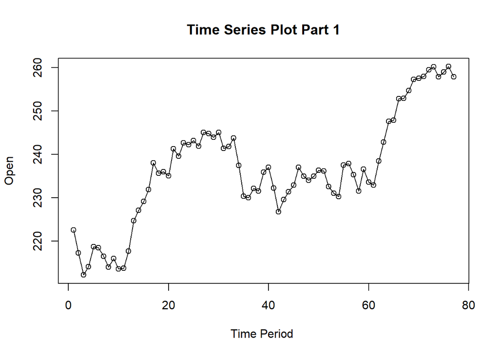

```r
ts.plot(data1, xlab="Time Period ", ylab="Open",
        main = "Time Series Plot Part 1")
points(data1)
```

### Plot ACF

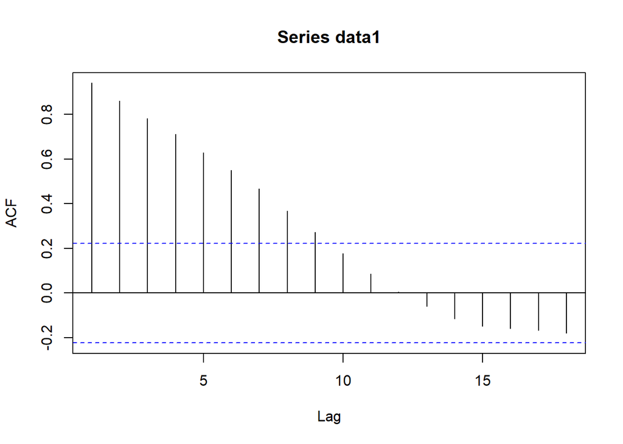

```r
acf(data1)
```

Berdasarkan plot ACF, terlihat bahwa plot ACF pada data partisi 1 tersebut cenderung *tails off slowly* maka data tersebut terindikasi tidak stasioner

### Uji ADF

```r
tseries::adf.test(data1)
```

```
##
##  Augmented Dickey-Fuller Test
##
## data:  data1
## Dickey-Fuller = -2.0584, Lag order = 4, p-value = 0.5517
## alternative hypothesis: stationary
```

$H_0$ : Data tidak stasioner dalam rataan

$H_1$ : Data stasioner dalam rataan

Berdasarkan uji ADF tersebut, didapat *p-value* sebesar 0.5517 yang lebih besar dari taraf nyata 5% sehingga terima $H_0$ dan menandakan bahwa data tidak stasioner dalam rataan. Hal ini sesuai dengan hasil eksplorasi menggunakan plot time series dan plot ACF.

### Plot Box-Cox

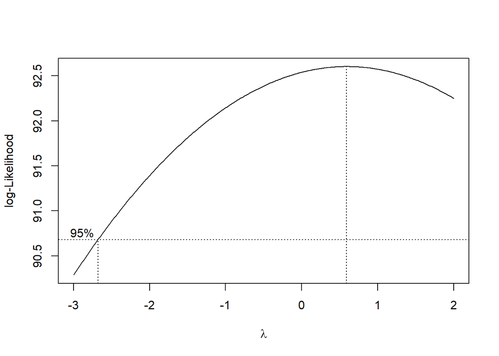

```r
index <- seq(1:77) #sebanyak row data
bc = boxcox(data1~index, lambda = seq(-3,2,by=0.01))
```

```r
#Nilai Rounded Lambda
lambda <- bc$x[which.max(bc$y)]
lambda
```

```
## [1] 0.59
```

```r
#SK
bc$x[bc$y > max(bc$y) - 1/2 * qchisq(.95,1)]
```

```
##   [1] -2.67 -2.66 -2.65 -2.64 -2.63 -2.62 -2.61 -2.60 -2.59 -2.58 -2.57 -2.56
##  [13] -2.55 -2.54 -2.53 -2.52 -2.51 -2.50 -2.49 -2.48 -2.47 -2.46 -2.45 -2.44
##  [25] -2.43 -2.42 -2.41 -2.40 -2.39 -2.38 -2.37 -2.36 -2.35 -2.34 -2.33 -2.32
##  [37] -2.31 -2.30 -2.29 -2.28 -2.27 -2.26 -2.25 -2.24 -2.23 -2.22 -2.21 -2.20
##  [49] -2.19 -2.18 -2.17 -2.16 -2.15 -2.14 -2.13 -2.12 -2.11 -2.10 -2.09 -2.08
##  [61] -2.07 -2.06 -2.05 -2.04 -2.03 -2.02 -2.01 -2.00 -1.99 -1.98 -1.97 -1.96
##  [73] -1.95 -1.94 -1.93 -1.92 -1.91 -1.90 -1.89 -1.88 -1.87 -1.86 -1.85 -1.84
##  [85] -1.83 -1.82 -1.81 -1.80 -1.79 -1.78 -1.77 -1.76 -1.75 -1.74 -1.73 -1.72
##  [97] -1.71 -1.70 -1.69 -1.68 -1.67 -1.66 -1.65 -1.64 -1.63 -1.62 -1.61 -1.60
## [109] -1.59 -1.58 -1.57 -1.56 -1.55 -1.54 -1.53 -1.52 -1.51 -1.50 -1.49 -1.48
## [121] -1.47 -1.46 -1.45 -1.44 -1.43 -1.42 -1.41 -1.40 -1.39 -1.38 -1.37 -1.36
## [133] -1.35 -1.34 -1.33 -1.32 -1.31 -1.30 -1.29 -1.28 -1.27 -1.26 -1.25 -1.24
## [145] -1.23 -1.22 -1.21 -1.20 -1.19 -1.18 -1.17 -1.16 -1.15 -1.14 -1.13 -1.12
## [157] -1.11 -1.10 -1.09 -1.08 -1.07 -1.06 -1.05 -1.04 -1.03 -1.02 -1.01 -1.00
## [169] -0.99 -0.98 -0.97 -0.96 -0.95 -0.94 -0.93 -0.92 -0.91 -0.90 -0.89 -0.88
```

[output cut: 24 more lines]

## Partisi Data Part 2

### Time Series

```r
data2 <- data.ts[78:154] |> ts()
data2
```

```
## Time Series:
## Start = 1
## End = 77
## Frequency = 1
##  [1] 261.66 261.58 256.08 255.46 249.74 253.40 250.97 249.06 246.45 252.15
## [11] 250.87 244.55 242.17 241.80 245.58 246.55 246.27 239.31 243.96 247.57
## [21] 247.79 251.77 251.43 251.17 251.00 251.23 248.13 245.22 247.76 249.98
## [31] 255.16 253.81 254.29 257.99 257.90 259.77 259.40 256.07 259.63 259.82
## [41] 262.72 265.99 266.16 266.23 266.19 268.87 270.69 269.61 272.82 278.03
## [51] 279.40 276.90 275.72 279.16 277.52 282.35 282.00 282.07 278.93 278.03
## [61] 278.90 283.84 287.37 289.00 289.43 288.99 286.24 285.17 286.36 285.42
## [71] 286.22 286.88 288.51 289.75 288.80 287.21 286.63
```

```r
mean(data2)
```

```
## [1] 265.0469
```

```r
var(data2)
```

```
## [1] 253.4297
```

#### Plot Time Series

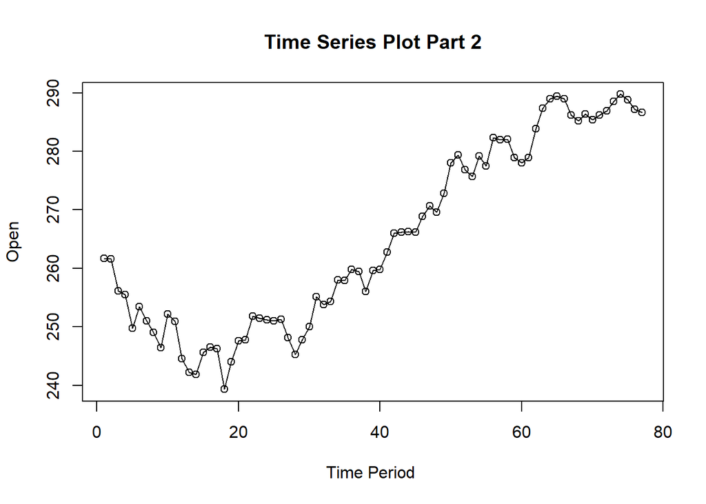

```r
ts.plot(data2, xlab="Time Period ", ylab="Open",
        main = "Time Series Plot Part 2")
points(data2)
```

### Plot ACF

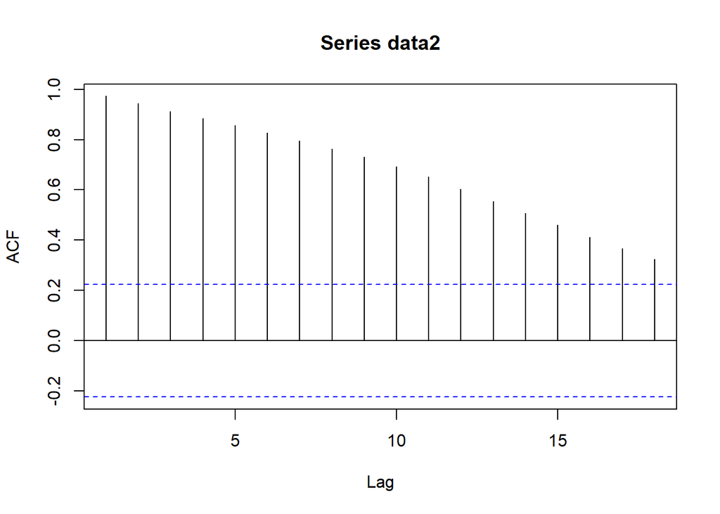

```r
acf(data2)
```

Berdasarkan plot ACF, terlihat bahwa plot ACF pada data partisi 2 tersebut cenderung *tails off* slowly maka data tersebut terindikasi tidak stasioner

### Uji ADF

```r
tseries::adf.test(data2)
```

```
##
##  Augmented Dickey-Fuller Test
##
## data:  data2
## Dickey-Fuller = -2.7942, Lag order = 4, p-value = 0.2512
## alternative hypothesis: stationary
```

$H_0$ : Data tidak stasioner dalam rataan

$H_1$ : Data stasioner dalam rataan

Berdasarkan uji ADF tersebut, didapat *p-value* sebesar 0.2512 yang lebih besar dari taraf nyata 5% sehingga terima $H_0$ dan menandakan bahwa data tidak stasioner dalam rataan. Hal ini sesuai dengan hasil eksplorasi menggunakan plot time series dan plot ACF.

### Plot Box-Cox

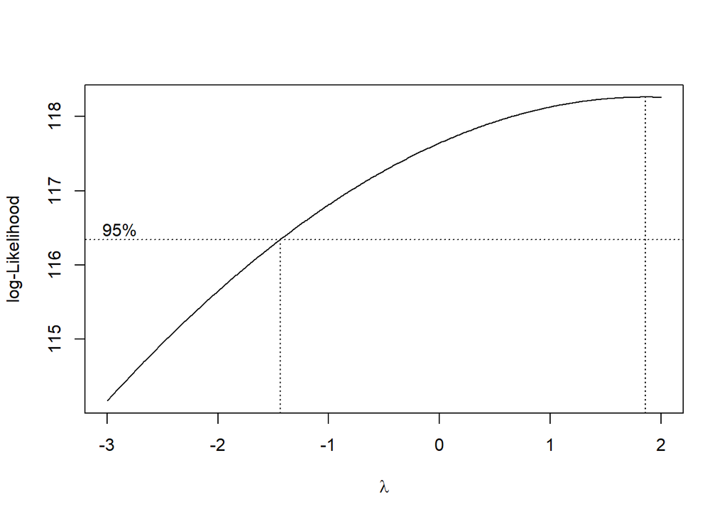

```r
index <- seq(78:154) #sebanyak row data
bc = boxcox(data2~index, lambda = seq(-3,2,by=0.01))
```

```r
#Nilai Rounded Lambda
lambda <- bc$x[which.max(bc$y)]
lambda
```

```
## [1] 1.86
```

```r
#SK
bc$x[bc$y > max(bc$y) - 1/2 * qchisq(.95,1)]
```

```
##   [1] -1.43 -1.42 -1.41 -1.40 -1.39 -1.38 -1.37 -1.36 -1.35 -1.34 -1.33 -1.32
##  [13] -1.31 -1.30 -1.29 -1.28 -1.27 -1.26 -1.25 -1.24 -1.23 -1.22 -1.21 -1.20
##  [25] -1.19 -1.18 -1.17 -1.16 -1.15 -1.14 -1.13 -1.12 -1.11 -1.10 -1.09 -1.08
##  [37] -1.07 -1.06 -1.05 -1.04 -1.03 -1.02 -1.01 -1.00 -0.99 -0.98 -0.97 -0.96
##  [49] -0.95 -0.94 -0.93 -0.92 -0.91 -0.90 -0.89 -0.88 -0.87 -0.86 -0.85 -0.84
##  [61] -0.83 -0.82 -0.81 -0.80 -0.79 -0.78 -0.77 -0.76 -0.75 -0.74 -0.73 -0.72
##  [73] -0.71 -0.70 -0.69 -0.68 -0.67 -0.66 -0.65 -0.64 -0.63 -0.62 -0.61 -0.60
##  [85] -0.59 -0.58 -0.57 -0.56 -0.55 -0.54 -0.53 -0.52 -0.51 -0.50 -0.49 -0.48
##  [97] -0.47 -0.46 -0.45 -0.44 -0.43 -0.42 -0.41 -0.40 -0.39 -0.38 -0.37 -0.36
## [109] -0.35 -0.34 -0.33 -0.32 -0.31 -0.30 -0.29 -0.28 -0.27 -0.26 -0.25 -0.24
## [121] -0.23 -0.22 -0.21 -0.20 -0.19 -0.18 -0.17 -0.16 -0.15 -0.14 -0.13 -0.12
## [133] -0.11 -0.10 -0.09 -0.08 -0.07 -0.06 -0.05 -0.04 -0.03 -0.02 -0.01  0.00
## [145]  0.01  0.02  0.03  0.04  0.05  0.06  0.07  0.08  0.09  0.10  0.11  0.12
## [157]  0.13  0.14  0.15  0.16  0.17  0.18  0.19  0.20  0.21  0.22  0.23  0.24
## [169]  0.25  0.26  0.27  0.28  0.29  0.30  0.31  0.32  0.33  0.34  0.35  0.36
## [181]  0.37  0.38  0.39  0.40  0.41  0.42  0.43  0.44  0.45  0.46  0.47  0.48
## [193]  0.49  0.50  0.51  0.52  0.53  0.54  0.55  0.56  0.57  0.58  0.59  0.60
## [205]  0.61  0.62  0.63  0.64  0.65  0.66  0.67  0.68  0.69  0.70  0.71  0.72
## [217]  0.73  0.74  0.75  0.76  0.77  0.78  0.79  0.80  0.81  0.82  0.83  0.84
## [229]  0.85  0.86  0.87  0.88  0.89  0.90  0.91  0.92  0.93  0.94  0.95  0.96
## [241]  0.97  0.98  0.99  1.00  1.01  1.02  1.03  1.04  1.05  1.06  1.07  1.08
## [253]  1.09  1.10  1.11  1.12  1.13  1.14  1.15  1.16  1.17  1.18  1.19  1.20
## [265]  1.21  1.22  1.23  1.24  1.25  1.26  1.27  1.28  1.29  1.30  1.31  1.32
## [277]  1.33  1.34  1.35  1.36  1.37  1.38  1.39  1.40  1.41  1.42  1.43  1.44
## [289]  1.45  1.46  1.47  1.48  1.49  1.50  1.51  1.52  1.53  1.54  1.55  1.56
## [301]  1.57  1.58  1.59  1.60  1.61  1.62  1.63  1.64  1.65  1.66  1.67  1.68
## [313]  1.69  1.70  1.71  1.72  1.73  1.74  1.75  1.76  1.77  1.78  1.79  1.80
## [325]  1.81  1.82  1.83  1.84  1.85  1.86  1.87  1.88  1.89  1.90  1.91  1.92
## [337]  1.93  1.94  1.95  1.96  1.97  1.98  1.99  2.00
```

## Partisi Data Part 3

### Time Series

```r
data3 <- data.ts[155:230] |> ts()
data3
```

```
## Time Series:
## Start = 1
## End = 76
## Frequency = 1
##  [1] 289.48 293.19 292.39 292.04 288.69 299.72 303.25 305.02 304.30 300.99
## [11] 298.99 301.12 304.42 302.87 302.20 300.99 301.01 299.78 300.82 298.42
## [21] 297.55 299.56 303.26 303.76 304.17 296.33 295.69 296.73 298.85 298.23
## [31] 296.14 289.80 285.10 285.71 282.12 287.40 284.05 285.78 295.18 296.22
## [41] 292.92 295.34 294.91 299.21 302.34 303.57 308.35 309.21 307.17 310.40
## [51] 309.36 311.00 316.00 324.33 324.13 331.36 330.31 333.90 332.89 338.51
## [61] 337.30 337.11 334.57 331.25 333.92 337.54 335.68 338.94 338.18 342.64
## [71] 344.62 337.05 336.28 334.35 334.94 335.32
```

```r
mean(data3)
```

```
## [1] 309.5555
```

```r
var(data3)
```

```
## [1] 330.0595
```

#### Plot Time Series

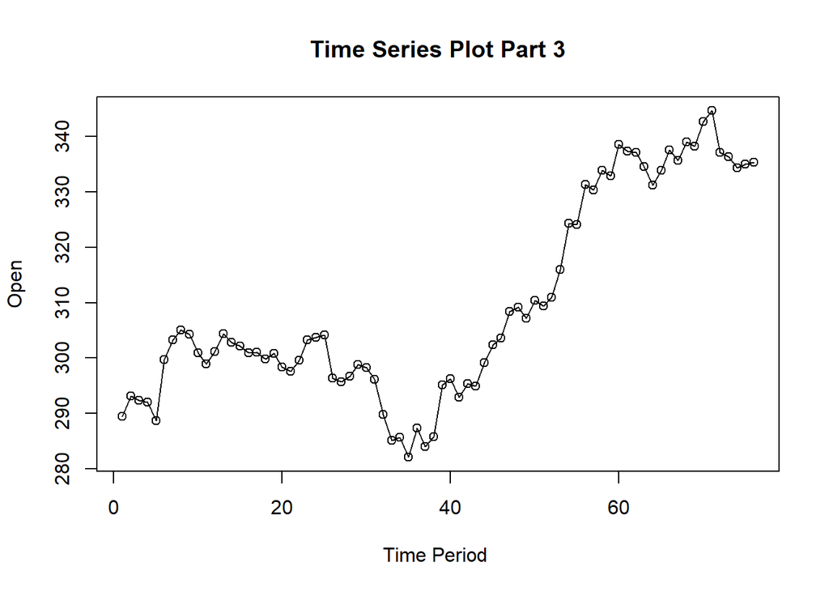

```r
ts.plot(data3, xlab="Time Period ", ylab="Open",
        main = "Time Series Plot Part 3")
points(data3)
```

### Plot ACF

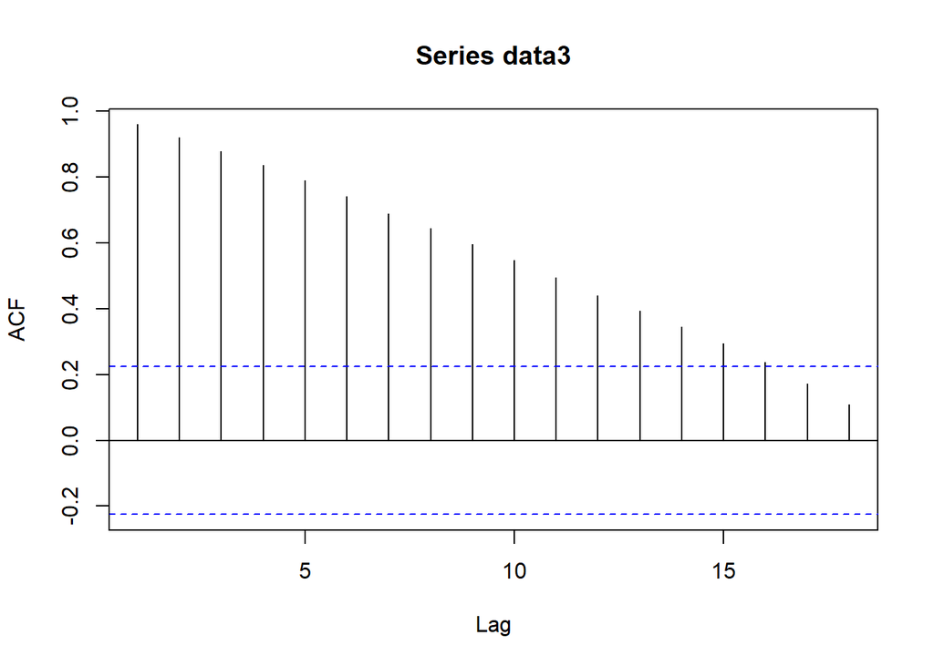

```r
acf(data3)
```

Berdasarkan plot ACF, terlihat bahwa plot ACF pada data partisi 3 tersebut cenderung *tails off* slowly maka data tersebut terindikasi tidak stasioner

### Uji ADF

```r
tseries::adf.test(data3)
```

```
##
##  Augmented Dickey-Fuller Test
##
## data:  data3
## Dickey-Fuller = -1.284, Lag order = 4, p-value = 0.8678
## alternative hypothesis: stationary
```

$H_0$ : Data tidak stasioner dalam rataan

$H_1$ : Data stasioner dalam rataan

Berdasarkan uji ADF tersebut, didapat *p-value* sebesar 0.8678 yang lebih besar dari taraf nyata 5% sehingga terima $H_0$ dan menandakan bahwa data tidak stasioner dalam rataan. Hal ini sesuai dengan hasil eksplorasi menggunakan plot time series dan plot ACF.

### Plot Box-Cox

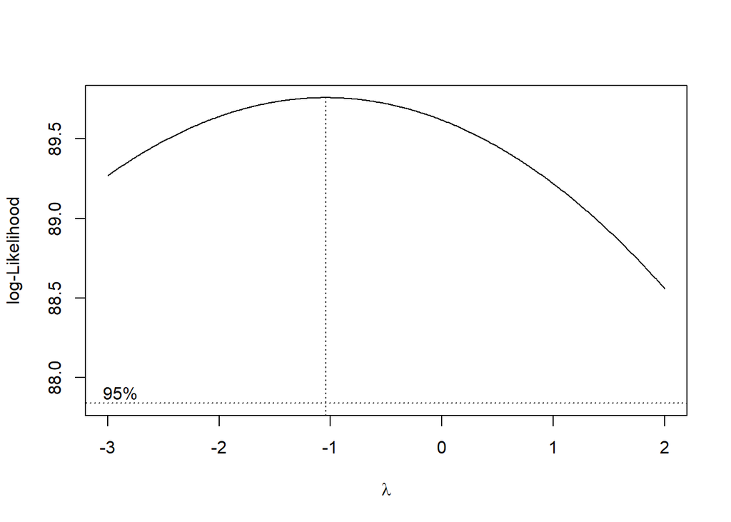

```r
index <- seq(155:230) #sebanyak row data
bc = boxcox(data3~index, lambda = seq(-3,2,by=0.01))
```

```r
#Nilai Rounded Lambda
lambda <- bc$x[which.max(bc$y)]
lambda
```

```
## [1] -1.04
```

```r
#SK
bc$x[bc$y > max(bc$y) - 1/2 * qchisq(.95,1)]
```

```
##   [1] -3.00 -2.99 -2.98 -2.97 -2.96 -2.95 -2.94 -2.93 -2.92 -2.91 -2.90 -2.89
##  [13] -2.88 -2.87 -2.86 -2.85 -2.84 -2.83 -2.82 -2.81 -2.80 -2.79 -2.78 -2.77
##  [25] -2.76 -2.75 -2.74 -2.73 -2.72 -2.71 -2.70 -2.69 -2.68 -2.67 -2.66 -2.65
##  [37] -2.64 -2.63 -2.62 -2.61 -2.60 -2.59 -2.58 -2.57 -2.56 -2.55 -2.54 -2.53
##  [49] -2.52 -2.51 -2.50 -2.49 -2.48 -2.47 -2.46 -2.45 -2.44 -2.43 -2.42 -2.41
##  [61] -2.40 -2.39 -2.38 -2.37 -2.36 -2.35 -2.34 -2.33 -2.32 -2.31 -2.30 -2.29
##  [73] -2.28 -2.27 -2.26 -2.25 -2.24 -2.23 -2.22 -2.21 -2.20 -2.19 -2.18 -2.17
##  [85] -2.16 -2.15 -2.14 -2.13 -2.12 -2.11 -2.10 -2.09 -2.08 -2.07 -2.06 -2.05
##  [97] -2.04 -2.03 -2.02 -2.01 -2.00 -1.99 -1.98 -1.97 -1.96 -1.95 -1.94 -1.93
## [109] -1.92 -1.91 -1.90 -1.89 -1.88 -1.87 -1.86 -1.85 -1.84 -1.83 -1.82 -1.81
## [121] -1.80 -1.79 -1.78 -1.77 -1.76 -1.75 -1.74 -1.73 -1.72 -1.71 -1.70 -1.69
## [133] -1.68 -1.67 -1.66 -1.65 -1.64 -1.63 -1.62 -1.61 -1.60 -1.59 -1.58 -1.57
## [145] -1.56 -1.55 -1.54 -1.53 -1.52 -1.51 -1.50 -1.49 -1.48 -1.47 -1.46 -1.45
## [157] -1.44 -1.43 -1.42 -1.41 -1.40 -1.39 -1.38 -1.37 -1.36 -1.35 -1.34 -1.33
## [169] -1.32 -1.31 -1.30 -1.29 -1.28 -1.27 -1.26 -1.25 -1.24 -1.23 -1.22 -1.21
```

[output cut: 27 more lines]